```r
## Bring in the required libraries
library(tidyverse)
library(tibble)
library(ggplot2)
library(reshape2)
library(cowplot)
```

# *Question 1:*

Find the value of one year european call and put options on a stock currently trading for \$50 with a strike price of $50. With a risk free rate of 5% and the underlying stock volatility of 40%

## Start by defining the terms

*s_0* is the current stock price.

*k* is the Current strike price.

*r* is the Risk Free Rate.

*sigma* is the volatility of underlying equity.

```r
D_1 <- function(s_0, k, r, sigma, time){

    ## Function to find d_1

    # Breaking the formula up into smaller parts
    a <- log(s_0 / k)
    b <- time * (r + ((sigma ^2 ) / 2))
    c <- sigma * sqrt(time)

    #Put the parts of the equation together
    d_1 <- (a + b) / (c)
    return(d_1)
}

d_1 <- D_1(s_0 = 50, k = 50, r = 0.05, sigma = 0.4, time = 1)
paste0('The value of d_1 is: ',d_1)
```

'The value of d_1 is: 0.325'

```r
D_2 <- function(s_0, k, r, sigma, time){

    ## Function to find d_2

    # Breaking up the formula up into smaller parts
    a <- log(s_0 / k)
    b <- time * (r - ((sigma ^2 ) / 2))
    c <- sigma * sqrt(time)

    # Put the parts of the equation together
    d_2 <- (a + b) / (c)
    return(d_2)
}

d_2 <- D_2(s_0 = 50, k = 50, r = 0.05, sigma = 0.4, time = 1)
paste0('The value of d_2 is: ',d_2)
```

'The value of d_2 is: -0.075'

```r
Call_Option <- function(k, s_0, d_1, r, time, d_2){

    ## Calculate the value of the call option

    ## Breaking up the formula into smaller parts
    a <- s_0 * pnorm(d_1)
    b <- k * exp(-r * time) * pnorm(d_2)
    c <- a - b
    return(c)
}

call_option <- Call_Option(k = 50, s_0 = 50, d_1 = d_1, r = 0.05, time = 1, d_2 = d_2)
paste0('The value of the call option is: ', call_option)
```

'The value of the call option is: 9.01147572510834'

```r
Put_Option <- function(k, s_0, d_1, r, time, d_2){

    ## Calculate the value of the put option

    ## Breaking up the formula into smaller parts
    a <- s_0 * pnorm(-d_1)
    b <- k * exp(-r * time) * pnorm(-d_2)
    return( -a + b)
}

put_option <- Put_Option(k = 50, s_0 = 50, d_1 = d_1, r = 0.05, time = 1, d_2 = d_2)
paste0('The value of the put option is: ', put_option)
```

'The value of the put option is: 6.57294695014404'

# *Question 2:*

Create a single function that can calculate the value of the call and put options. Output in a single variable

```r
Black_Scholes_Merton <- function(k, s_0, r, time, sigma){
    ### Use the previously created functions to create the Black Scholes Model

    ## Find the values for d_1 and d_2
    d_1 <- D_1(s_0, k, r, sigma, time)
    d_2 <- D_2(s_0, k, r, sigma, time)

    ## Find the values for the call and put options
    c <- Call_Option(k, s_0, d_1, r, time, d_2)
    p <- Put_Option(k, s_0, d_1, r, time, d_2)

    ## Return the call and put option values as a list
    return(list('call' = c,
               'put' = p))
}

## Use the Black Scholes Merton formula
q_2 <- Black_Scholes_Merton(k = 50, s_0 = 50, r = 0.05, time = 1, sigma = 0.4)

paste0('The price of the call option is: ', q_2$call)
paste0('The price of the put option is: ', q_2$put)
```

'The price of the call option is: 9.01147572510834'

'The price of the put option is: 6.57294695014404'

# *Question 3:*

Compute the value of the options for various strike prices ranging from 40 to 60 in \$0.10 increments

```r
### Start by defining the terms
s_0 <- 50 ## current stock price
r <- 0.05 ## Risk Free Rate
sigma <- 0.4 ## volatility of underlying equity
time <- 1 ## Time to maturity (in days)
```

```r
## Create a dataframe with K = the sequence of the strike price
q_3 <- tibble('K' = seq(40, 60, 0.1))

## Add the call and put options to the dataframe
q_3$Call <- Black_Scholes_Merton(q_3$K,
                           s_0, r, time, sigma)$call
q_3$Put <- Black_Scholes_Merton(q_3$K,
                           s_0, r, time, sigma)$put

head(q_3, 5)
```

| K | Call | Put |
| --- | --- | --- |
| 40.0 | 14.48820 | 2.537381 |
| 40.1 | 14.42311 | 2.567412 |
| 40.2 | 14.35823 | 2.597654 |
| 40.3 | 14.29356 | 2.628108 |
| 40.4 | 14.22910 | 2.658772 |

# *Question 4:*

Call the function recursively in a for loop and save in a dataframe for the same range for the strike price

```r
For_Loop_Black_Scholes <- function(s_0, r, time, sigma){
    ## Create a dataframe that has the K value, the Call option value,
    ## and the Put option value

    df <- tibble(K = numeric(),
              Call = numeric(),
              Put = numeric())

    for (i in seq(40, 60, 0.1)){
        ## Recursively go through the strike price sequence
        ## and find the call and put option values

        ## Add row using tidyverse for both the call and the put options.
        df <- df %>% add_row(K = i,
                              Call = Black_Scholes_Merton(i, s_0,
                                                         r, time, sigma)$call,
                               Put = Black_Scholes_Merton(i, s_0,
                                                         r, time, sigma)$put)

    }
     return(df)

}

q_4 <- For_Loop_Black_Scholes(s_0 = 50,
                             r = 0.05, time = 1, sigma = 0.4)
head(q_4)
```

| K | Call | Put |
| --- | --- | --- |
| 40.0 | 14.48820 | 2.537381 |
| 40.1 | 14.42311 | 2.567412 |
| 40.2 | 14.35823 | 2.597654 |
| 40.3 | 14.29356 | 2.628108 |
| 40.4 | 14.22910 | 2.658772 |
| 40.5 | 14.16486 | 2.689649 |

# *Question 5:*

Repeat the function from question 4 but use the apply function

```r
q_5 <- tibble(K = seq(40, 60, 0.1) )

Black_Scholes_Merton_Call <- function(x){
    ## Find the call option value using the apply function
    return(Black_Scholes_Merton(k = x, s_0, r, time, sigma)$call)
}

Black_Scholes_Merton_Put <- function(x){
    ## Find the put option value using the apply function
    return(Black_Scholes_Merton(k = x, s_0, r, time, sigma)$put)
}
q_5$Call <- sapply(q_5$K,Black_Scholes_Merton_Call)
q_5$Put <- sapply(q_5$K, Black_Scholes_Merton_Put)

head(q_5)
```

| K | Call | Put |
| --- | --- | --- |
| 40.0 | 14.48820 | 2.537381 |
| 40.1 | 14.42311 | 2.567412 |
| 40.2 | 14.35823 | 2.597654 |
| 40.3 | 14.29356 | 2.628108 |
| 40.4 | 14.22910 | 2.658772 |
| 40.5 | 14.16486 | 2.689649 |

# *Question 6:*

```r
Relation <- function(df, r, time, s_0) {
    ## Function to find put and call option parity

    df$Left_Relation <- df$Call + df$K * exp(-r * T)
    df$Right_Relation <- df$Put + s_0
    return(df)
}

## Use the relation formula to find the values for the left and the right side of the
## put-call parity formula
q_3_relation <- Relation(q_3, r = 0.05, time = 1, s_0 = 50)
q_4_relation <- Relation(q_4, r = 0.05, time = 1, s_0 = 50)
q_5_relation <- Relation(q_5, r = 0.05, time = 1, s_0 = 50)
```

```r
Plot_Put_Call_Options <- function(df){
    ## Create a plot for the put and call Option values vs Strike Price

    ggplot(data = melt(df, id.var = 'K'),
          aes(x = K, y = value, col = variable)) +
        geom_line() +
        labs(x = 'Strike Price K ($)', y = 'Option Value ($)',
            colour = 'Variables', title = 'Strike Prices vs Option Prices')
}

Plot_Put_Call_Parity <- function(df){
    ## Create plots for the put and call parity
    ## To see that the relation holds

    ggplot(data = df, aes(x = Left_Relation, y = Right_Relation)) +
        geom_line() +
        labs(x = 'Put Call Left Side', y = 'Put Call Right Side',
             title = 'Put Call Parity')
}
```

Once we have the values for the option prices (put and call) as well as the values for the right and the left hand sides of the put-call parity equation, we can then plot these.

We are looking at the put-call parity relation to see whether or not the relation is held

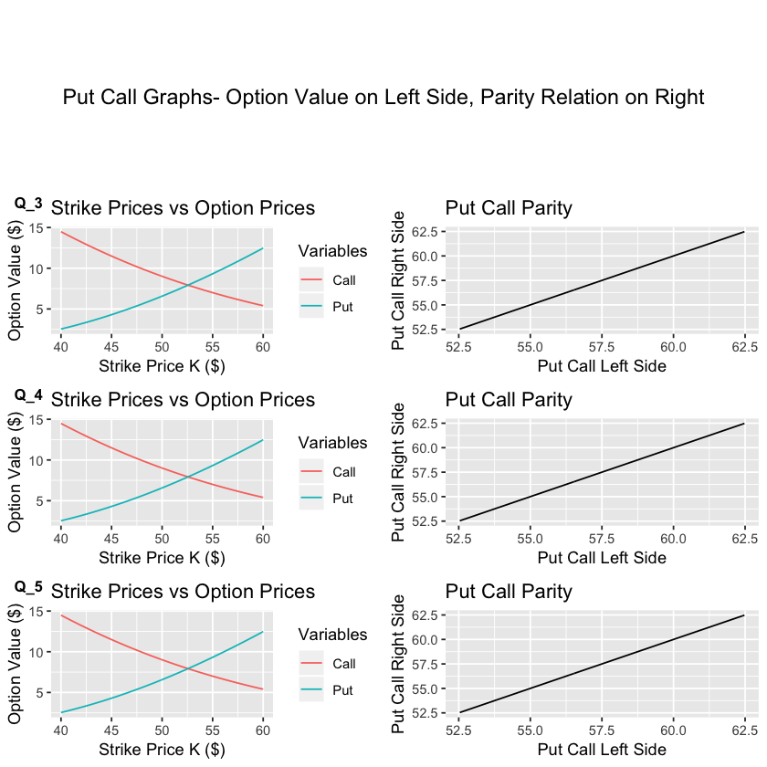

```r
overall_title <- ggdraw() +
    draw_label('Put Call Graphs- Option Value on Left Side, Parity Relation on Right')


q_3_plot <- plot_grid(Plot_Put_Call_Options(q_3),
         Plot_Put_Call_Parity(q_3_relation))

q_4_plot <- plot_grid(Plot_Put_Call_Options(q_4),
          Plot_Put_Call_Parity(q_4_relation))

q_5_plot <- plot_grid(Plot_Put_Call_Options(q_5),
          Plot_Put_Call_Parity(q_5_relation))

plot_grid(overall_title, q_3_plot, q_4_plot, q_5_plot, ncol = 1,
         labels = c('', 'Q_3', 'Q_4', 'Q_5'), label_size = 10)
```

As we can see in the graphs above, the relationship for the put-call parity holds (comparing the left hand side of the equation with the right hand side of the equation).